# Higher β‐diversity observed for herbs over woody plants is driven by stronger habitat filtering in a tropical understory - Murphy - 2016 - Ecology - Wiley Online Library

Login / Register

[Ecology](https://esajournals.onlinelibrary.wiley.com/journal/19399170)

[Volume 97, Issue 8](https://esajournals.onlinelibrary.wiley.com/toc/19399170/2016/97/8) p. 2074-2084

[figure not shown]

Article

Full Access

# Higher β-diversity observed for herbs over woody plants is driven by stronger habitat filtering in a tropical understory

[Stephen J. Murphy](https://esajournals.onlinelibrary.wiley.com/action/doSearch?ContribAuthorStored=Murphy%2C+Stephen+J),

E-mail:

[Kara Salpeter](https://esajournals.onlinelibrary.wiley.com/action/doSearch?ContribAuthorStored=Salpeter%2C+Kara),

[Liza S. Comita](https://esajournals.onlinelibrary.wiley.com/action/doSearch?ContribAuthorStored=Comita%2C+Liza+S),

First published: 28 March 2016

https://doi.org/10.1890/15-1801.1

Citations: 14

Corresponding Editor: R. T. Corlett

## Introduction

The majority of the world's terrestrial biodiversity is housed in tropical forests (von Humboldt 1807, Wallace 1878), with plant richness in some cases exceeding 650 tree and shrub species/ha (Valencia et al. 2004). The high local diversity of tropical forests poses a daunting challenge to ecologists, who have long sought to explain how so many species coexist without one superior competitor becoming dominant (Gause 1934, Wright 2002). Despite the attention given to tropical plant diversity, the vast majority of research on the subject has focused exclusively on woody individuals (i.e., trees, shrubs, and lianas). These studies have greatly improved our understanding of both patterns of woody plant diversity, as well as the underlying processes generating them (Wright 2002). However, in contrast to the large number of studies conducted on woody plants, studies on tropical herbaceous plant diversity and composition remain rare, particularly at local scales (Royo and Carson 2005). This places our knowledge of tropical herbaceous communities well behind that for trees and lianas, and severely limits our ability to recognize and understand the full extent of tropical plant diversity as a whole.

Surprisingly, the lack of studies on the herbaceous layer in the tropics lies in stark contrast to temperate forests, where the herbaceous groundflora has received much attention over the past decades (Whigham 2004, Gilliam 2007, and Gilliam 2014 for reviews). This focus on temperate forest herbs has been driven largely by the recognition that they contribute significantly to forest community diversity, comprising 80% of total plant species richness on average (Gilliam 2007). In addition, studies have shown that temperate forest herbs influence tree seedling regeneration (Royo and Carson 2006), provide evidence of niche partitioning (Gilbert et al. 2004), and mediate many important ecosystem processes such as nutrient cycling (Muller 2014). Herbs have similarly been shown to contribute substantially to the diversity of tropical forests, representing 50% of the species richness in some cases (Gentry and Dodson 1987, Linares-Palomino et al. 2009). However, in comparison to temperate forests, research on tropical herbaceous communities, beyond their contributions to total species counts, is severely lacking.

Similarly, research on the beta-diversity of tropical herbs is also scant compared to the large body of literature on both tropical woody plant and temperate herb beta-diversity. Of the few studies that have looked at spatial variation in tropical herb communities, most have either focused only on the most common species (Svenning et al. 2004), have restricted sampling to specific taxa such as palms or ferns (Vormisto et al. 2000, Tuomisto and Ruokolainen 2003, Tuomisto et al. 2003, Zuquim et al. 2012), have only sampled flowering or fruiting individuals (Gentry and Emmons 1987), or do not include abundance data (Svenning et al. 2004). Furthermore, all of these studies have focused on large spatial scales (i.e., landscape to regional).

One area where information is particularly lacking is in our understanding of how environmental resource gradients shape herb distribution patterns (i.e., local habitat filtering). Tropical woody species have been shown to associate with both topographic (Webb and Peart 2000, Harms et al. 2001, Kanagaraj et al. 2011, De Cáceres et al. 2012) and soil nutrient gradients (John et al. 2007, Dalling et al. 2012). Furthermore, the strength and type of habitat filtering have been shown to differ among life stages (e.g., between seedlings, saplings and adult trees) (Webb and Peart 2000, Comita et al. 2007b, Kanagaraj et al. 2011, Dalling et al. 2012) and among growth forms (e.g., lianas vs. trees; Dalling et al. 2012) in tropical forests, suggesting that patterns found for adult trees are not necessarily generalizable. There are good reasons to expect that herbs may respond differently to resource gradients than do woody species. For example, herbs are often more sensitive to drought due to their lower rooting depth and lack of secondary tissue (Costa 2006). Herbs may also be more sensitive to pathogen and herbivore loads (Royo and Carson 2005), which have themselves been shown to correlate strongly with environmental variables such as light and moisture (Augspurger 1984). Furthermore, herbs are highly dispersal limited, which also leads to aggregated patterns (Leigh et al. 2004).

To help fill these gaps, we present results from a census of the herbaceous groundlayer of an intensively studied 50-ha forest dynamics plot on Barro Colorado Island (BCI), Panama. We compare spatial patterns of diversity and composition between the understory herbaceous and woody plant communities (i.e., tree, shrub and liana seedlings), focusing on three questions: (1) How do alpha- and beta-diversity differ between herbaceous and woody seedlings in a tropical forest understory community? We expected herbs to contribute significantly to overall community richness, but herb richness to be lower than total woody richness (Croat 1978). However, we expected herbs to exhibit stronger spatial aggregation (i.e., higher beta-diversity) than woody individuals due to greater resource sensitivity and dispersal limitation. (2) Do herbs and woody seedlings show similar spatial patterns in alpha and beta-diversity? In other words, are sites with high woody richness also home to high herb richness, and are sites with unique woody communities also home to unique herb communities? If woody and herbaceous communities respond similarly to environmental resource gradients, we would expect to see strong correlations in local alpha- and beta-diversity between them. Alternatively, if different processes regulate these growth forms, or if competition between them is strong, we may expect to see weak or even negative correlations. To explore this question further, we asked (3) Do the actual processes generating observed spatial patterns of alpha and beta-diversity differ between herbs and woody seedlings? We hypothesized that habitat filtering would be strongest for herbs, resulting in greater habitat associations and stronger correlations with environmental variables.

## Materials and Methods

### Study site

The study was conducted in the 50-ha forest dynamics plot on Barro Colorado Island (BCI), Panama (9°10′ N, 79°51′ W) (Condit 1998, Hubbell et al. 1999, 2005). The vegetation is seasonal tropical moist forest, and the island receives ~2600 mm of precipitation per year, with a distinct dry season from January to April (Windsor 1990). All stems ≥1 cm diameter at breast height (DBH) in the BCI 50-ha plot are tagged, mapped, and measured at five year intervals.

### Woody seedlings census

Since 2001, tree, shrub and free-standing liana seedlings ≥20 cm tall and <1 cm DBH have been tagged, mapped and measured every 1–2 years in ~20,000 1 × 1 m seedling plots that are spaced at 5-m intervals throughout the 50-ha BCI plot (Comita et al. 2007a, 2010, Comita and Hubbell 2009). For all analyses, we considered liana seedlings separately from tree and shrub seedlings (hereafter referred to simply as tree seedlings) because of their distinct growth form and ecological strategy (Putz 1984, Dalling et al. 2012).

### Herb census

In 2012, we conducted a census of the herbaceous understory community in a subset of the 20,000 seedling plots (Salpeter 2013). We employed a stratified random sampling design based on topographic habitat types defined by Harms et al. (2001). The four primary habitat types were “high-plateau,” “low-plateau,” “slope,” and “swamp,” and within each of these habitat types, thirty 20 × 20 m quadrats were randomly selected for herb sampling. Only 26 quadrats were sampled in the swamp habitat and 29 in the slope habitat to avoid existing trails, resulting in 115 total 20 × 20 m quadrats and 1840 1 × 1 m plots (Appendix S1: Fig. S1). For this study, we defined herbs as all non-woody rooted vascular plants that were not twining around or climbing another individual at the time of the census. Herbaceous climbers were not included in the census due to their differences in life-history strategy, as well as to avoid problems with sampling. In particular, sampling of climbers was made difficult due to the fact that they were often rooted outside of the plot, and measuring percent cover was difficult for very tall individuals. In nearly all cases, unidentified species were readily distinguishable from one another and were thus retained in all analyses as morphospecies.

### Measuring abundance

In all analyses, RIVs were first square-root transformed to reduce the impacts of highly abundant species. Furthermore, to ensure that the particular RIV metric used did not greatly influence our results, we reran all analyses using several different combinations of abundance metrics, and found that our results were highly consistent and did not change any conclusions (Appendix S2).

### Environmental data

Topographic variables included mean elevation, aspect, slope steepness, and convexity of each 20 × 20 m quadrat. A topographic wetness index (TWI) was also calculated from a 5-m scale resolution digital elevation map (Hengl 2009). Aspect data were sin- and cos-transformed to avoid problems with circularity, and both variables were used in all subsequent analyses (Legendre et al. 2009). Data on soil chemistry (i.e., pH, Al, B, Ca, Cu, Fe, K, Mg, Mn, Zn, NH<sub>4</sub>+ and NO<sub>3</sub>) in the BCI 50-ha plot were also used (Dalling et al. 2014). These data were sampled at a 50-m resolution and then kriged for use at the 20 × 20 m scale (Dalling et al. 2014). Because of the large numbers of individual soil variables used, they were first reduced using principal components analysis, and the first axis was used to describe overall soil fertility (John et al. 2007).

Understory light availability was estimated using canopy height survey data collected in 2012 (Hubbell et al. 2014). For every 5 × 5 m subsection of the 50-ha plot, the presence/absence of vegetation at incremental heights above ground level was recorded (i.e., 0–1 m, 1–2 m, 2–5 m, 5–10 m, 10–20 m, 20–30 m, and above 30 m). These data were then used to calculate a shade index for each 5 × 5 m quadrats, and averaged for each 20 × 20 m quadrat used here.

### Species richness and diversity

For each growth form and each habitat type, we calculated species richness, the Chao-1 richness estimator (to correct for undersampling; Appendix S1: Fig. S2; Chao 1984), the exponentiated Shannon-Wiener diversity index, and the undersampling-corrected Chao-Shen index (Chao and Shen 2003).

### Beta-diversity

Following the advice of Anderson et al. (2011), we used several methods for quantifying beta-diversity: (1) Whittaker's multiplicative estimate (β<sub>Whit</sub>), (2) the mean Morisita-Horn distance ( ), and (3) and the total variance of the site-by-species matrix [SS(**Y**)]. SS(**Y**), which was calculated using the Hellinger-transformed site-by-species matrix (Legendre and Gallagher 2001), is useful because it allows for the partitioning of beta-diversity into individual site and species contributions (Legendre et al. 2005, Legendre and De Cáceres 2013). Here, we use the local site contribution to beta-diversity (LCBD) to test whether the sites contributing the most to beta-diversity differed among growth forms (i.e., question 2 in *Introduction*). We used a null model to control for differences in total species pools among the three growth forms by randomly shuffling the identities of species within plots a total of 999 times and calculating the mean and standard deviations of each null-derived beta-metric (Chase et al. 2011, Kraft et al. 2011). Because the null model requires true count data, only frequency values were used when calculating beta-diversity.

### Habitat filtering

For each growth form, we examined species composition among the four topographic habitat types using nonmetric multidimensional scaling ordination (NMDS) with Morisita-Horn dissimilarities, and tested for significant differences using permutational multivariate ANOVA (PERMANOVA; Anderson 2001). We also used indicator species analysis to determine which species from each strata were positively associated with each of the four habitat types (Dufrêne and Legendre 1997). We next used variance partitioning using the continuous environmental variables measured. We partitioned the variation in richness and composition into individual fractions explained by both environment (i.e., topographic variables, soil fertility, and shade) and spatial descriptors. Principal coordinates of neighbor matrices (PCNMs) were used as spatial descriptors (Dray et al. 2006). PCNMs that were significantly correlated with richness and composition were identified using forward selection, and fractions of explained variation were measured using adjusted *R*-squared values (Borcard et al. 1992). All analyses were done in the R statistical programming language (R Core Team 2015) using the “vegan” package (Oksanen 2011) for community analyses and the “packfor” package (Dray et al. 2011) for forward selection.

## Results

### Alpha- and beta-diversity of the herbaceous vs. woody community

Table 1. Alpha- and beta-diversity estimates for herbs, tree, and liana seedlings within the BCI 50-ha plot. For the species richness and Shannon estimates, values are given for the community as a whole, as well as for each individual habitat type

|  | Habitat | Alpha-diversity Richness | Alpha-diversity Chao1 | Alpha-diversity exp(*H*′) | Alpha-diversity exp(*H*′<sub>Chao</sub>) | Beta-diversity β<sub>W</sub> | Beta-diversity β<sub>WC</sub> | Beta-diversity | Beta-diversity SS(**Y**) | n |  |
| --- | --- | --- | --- | --- | --- | --- | --- | --- | --- | --- | --- |
| Herbs | All | 54 | 68 ± 10 | 18.83 | 19.28 | 24.03 | 24.14 | 14.83 | 10.59 |  | 115 |
|  | Hi Plateau | 24 | 30 ± 6 | 11.77 | 13.02 | – | – | – | – | 30 |  |
|  | Low Plateau | 29 | 45 ± 16 | 14.09 | 14.93 | – | – | – | – | 30 |  |
|  | Slope | 28 | 35 ± 6 | 12.55 | 13.44 | – | – | – | – | 29 |  |
|  | Swamp | 41 | 61 ± 14 | 23.84 | 26.60 | – | – | – | – | 26 |  |
| Tree seedlings | All | 166 | 204 ± 16 | 60.77 | 66.05 | 19.25 | 20.08 | 11.20 | 9.06 | 115 |  |
|  | Hi Plateau | 87 | 114 ± 13 | 44.50 | 50.28 | – | – | – | – | 30 |  |
|  | Low Plateau | 98 | 164 ± 31 | 52.06 | 59.27 | – | – | – | – | 30 |  |
|  | Slope | 107 | 155 ± 20 | 57.67 | 66.97 | – | – | – | – | 29 |  |
|  | Swamp | 98 | 206 ± 49 | 50.21 | 61.06 | – | – | – | – | 26 |  |
| Liana seedlings | All | 73 | 91 ± 11 | 34.54 | 37.58 | 15.68 | 15.00 | 6.53 | 5.54 | 115 |  |
|  | Hi Plateau | 43 | 55 ± 8 | 24.63 | 29.70 | – | – | – | – | 30 |  |
|  | Low Plateau | 45 | 54 ± 7 | 29.71 | 34.06 | – | – | – | – | 30 |  |
|  | Slope | 52 | 95 ± 26 | 31.39 | 37.81 | – | – | – | – | 29 |  |
|  | Swamp | 44 | 57 ± 8 | 27.54 | 35.26 | – | – | – | – | 26 |  |

### Correlations in local diversity and composition among sites

Herbs and woody seedlings differed in their spatial patterns of alpha diversity. Among habitat types, herb species richness was highest in the swamp, while for tree and liana seedlings, slopes generally contained the most species (Table 1). Over the entire plot, there was no correlation between the number of herb and tree seedling species per 20 × 20 m quadrat (*r = −*0.10, *P* = 0.27; Fig. 1a), nor between herb and liana richness (*r =* 0.06, *P* = 0.53). In contrast, there was a strong positive correlation between tree seedling and liana seedling richness (*r =* 0.44, *P* < 0.01; Fig. 1a). These results were similar when using the Shannon-Wiener index (herbs:tree seedlings: *r* = −0.11, *P* = 0.22; herbs:liana seedlings: *r* = 0.07, *P* = 0.46; tree seedlings:liana seedlings: *r* = 0.41, *P* < 0.01). Likewise, individual sites with unique species compositions were not the same for herbaceous and woody communities (Fig. 1b). Local site contributions to beta-diversity (LCBD) were uncorrelated between herbs and tree seedlings (*r =* 0.15, *P* = 0.11), as well as between herbs and liana seedlings (*r* = 0.08, *P* = 0.42). As with alpha diversity, tree seedling and liana seedling LCBD values were significantly correlated (*r* = 0.33, *P* < 0.01).

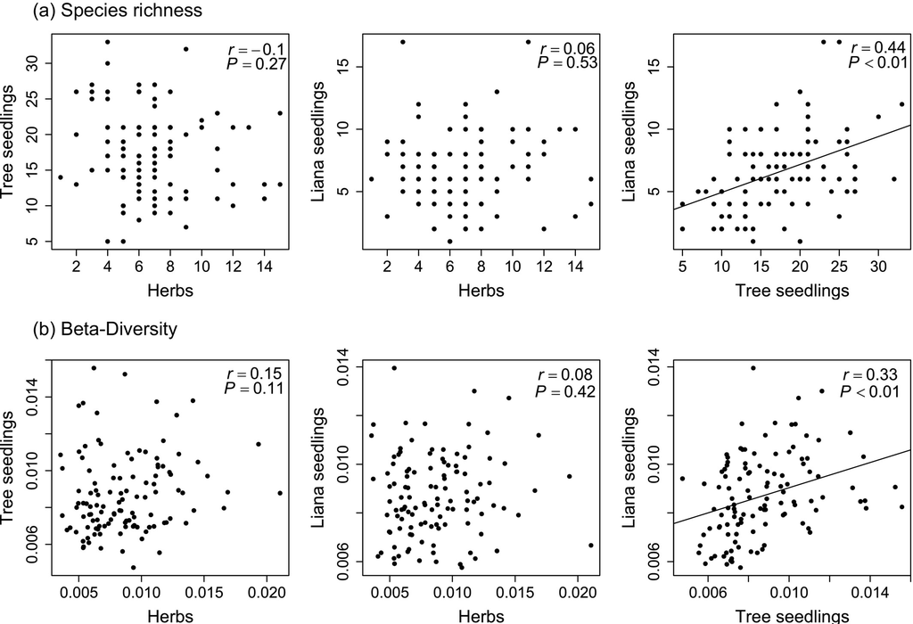

**Figure 1**

Open in figure viewer[PowerPoint](https://esajournals.onlinelibrary.wiley.com/action/downloadFigures?id=ecy1429-fig-0001&doi=10.1890%2F15-1801.1)

Scatter plots and correlations between herbaceous plants, tree seedlings, and liana seedlings for local species richness and local site contributions to beta-diversity (LCBD). Each point represents a 20 × 20 m quadrat. LCBD values are the sums of squared deviations from the community-wide mean for individual quadrats. Best-fit line shown for significant correlations.

### Habitat associations and response to resource gradients

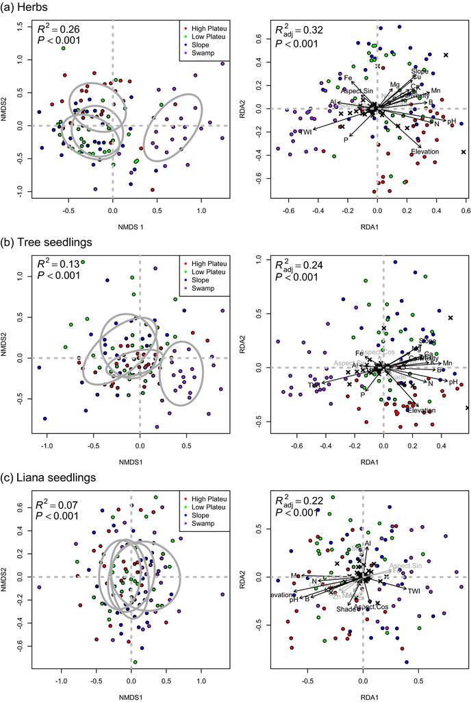

**Figure 2**

Open in figure viewer[PowerPoint](https://esajournals.onlinelibrary.wiley.com/action/downloadFigures?id=ecy1429-fig-0002&doi=10.1890%2F15-1801.1)

Non-metric multidimensional scaling (NMDS) ordination (left panels) showing the locations of 115 sampling quadrats in species-space. Points are color-coded according to habitat type, and 95% confidence ellipses are overlain. An outlier that severely influenced the results of the NMDS for liana seedlings was removed from the analysis. Permutational multivariate ANOVA (PERMANOVA) results (Pseudo *R*-squared statistic and associated *P*-value) are shown in the top left corner. Redundancy analysis (RDA; right panels) showing the relationship between community composition and individual measured environmental variables. Adjusted *R*-squared values and *P*-values are shown in the top left corner. In all panels, the *x*-axis represents ordination axis 1, and the *y*-axis represents axis 2.

Variance partitioning models explained the highest amount of total variation for herb richness and species composition (Fig. 3). Environment alone explained little of both herb and tree seedling richness, but the shared fraction and spatial fractions were highest for herbs (Fig. 3a). For species composition, all three communities had similar fractions explained only by the environment, but the shared and spatial fractions were again much higher for herbs (Fig. 3b). The three growth forms varied widely in their correlations with individual environmental variables, but the variation explained by each was nearly always highest for herbs (Appendix S1: Fig. S5). For species composition, elevation and TWI were important environmental variables for all three growth forms, and shade index was only important for herb richness.

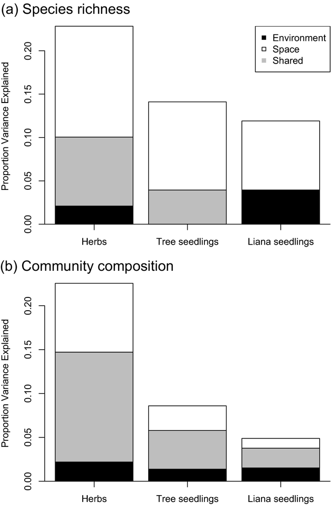

**Figure 3**

Open in figure viewer[PowerPoint](https://esajournals.onlinelibrary.wiley.com/action/downloadFigures?id=ecy1429-fig-0003&doi=10.1890%2F15-1801.1)

Variance partitioning models showing individual fractions of variation explained by environmental and spatial descriptor variables (PCNMs). The top panel shows results for species richness (a), and the bottom panel for species composition (b). Environment (black) and space (white) fractions indicate unique contributions towards the overall amount of variance explained, and the gray fraction indicates the redundant portion co-explained by each.

## Discussion

We found that the herbaceous groundlayer of a well-studied neotropical forest contributes substantially to overall understory diversity. Including non-scandent herbaceous plants increased total understory plant species richness by 22% compared to estimates based solely on woody seedlings. Individual herb species were more highly aggregated than their woody neighbors, resulting in higher overall beta-diversity, which our results suggest is due to stronger habitat associations and dispersal limitation. Interestingly, across site correlations in diversity between herbaceous and woody communities were not significant, likely driven by the differential responses of growth forms to environmental resource gradients. Our results suggest that contrasting mechanisms structure herbaceous and woody communities, which helps further our understanding of tropical forest community assembly and diversity.

### Understory alpha- and beta-diversity

The contribution of herbs to total species richness reported here (18% of all understory species sampled) was lower than that recorded in Croat (35.4%; 1978). However, the Croat census was conducted across the entire 15.6-km<sup>2</sup> island and included clearings, trails, shorelines, and successional areas where herbs are more highly abundant. The relatively low overall percent coverage values for the herbaceous community recorded within the 50-ha plot explains, in part, why herb species richness was lower than for woody seedlings. Despite this observation, the 54 herb species recorded indicate that herbs are capable of coexisting with each other, as well as with woody species in the BCI community, albeit at low abundances. Furthermore, our estimate of herbaceous richness is certainly an underestimate due to the fact that climbing vines and epiphytes were not included in our census.

In contrast to alpha-diversity, beta-diversity was highest for herbs, suggesting three possible scenarios: (1) herbs are more sensitive to environmental resource gradients or habitat-type than woody seedlings; (2) interspecific variation in response to resources or habitats is highest in herbs; and/or (3) herbs are more dispersal limited than woody individuals. Previous work on temperate herbs indicates that herbaceous plants are highly sensitive to fine-scale variation in soil moisture and light gradients (Gilliam 2007, Neufeld and Young 2014). Specifically, the shallow and rhizomatous rooting nature of forest herbs, as well as their lack of secondary tissue, greatly increases wilting risk (Weatherley and Slatyer 1957, Kennedy and Booth 1958, Poulsen 1996, Whigham 2004, Costa et al. 2005). Similarly, the fact that ground herbs occupy the lowest canopy strata in forests makes them highly dependent on spatially variable and transient solar events such as sun flecks (Chazdon and Pearcy 1991). If herbs partition light gradients more strongly than woody seedlings, we would expect to see higher aggregation such as observed here. In general, interspecific variation in functional traits and life-history strategy may be greater for herbs than for woody seedlings (Whigham 2004). Germination requirements in particular are highly specific and vary among herbaceous species (Bierzychudek 1982, Whigham 2004). Likewise, herbs are highly dispersal limited due to their short stature and small fruit size that limits animal dispersal, leading to greater aggregation.

For both liana and tree seedlings, it is worth pointing out that the lower beta-diversity observed could be due to the fact that these communities have not yet experienced a long enough time interval for environmental filtering effects to become evident. The average lifespans of these growth forms are much longer than for herbs, and it is possible for habitat associations of trees and shrubs to change in strength through time (i.e., from seedling to saplings to adults; Webb and Peart 2000). Indeed, environmental filtering has been shown to strengthen topographic habitat associations over time for both shrubs and trees at our study site (Comita et al. 2007b, Kanagaraj et al. 2011). To explore this idea further, we conducted an additional post-hoc analysis on the habitat associations of adult trees found within the same 20 × 20 m quadrats where herbs were sampled. We found that the strength of habitat partitioning was still greatest for herbs, although adult trees did show stronger correlations with both the habitat categories (PERMANOVA results: *F* = 7.17, *R*<sup>2</sup> = 0.16) and to the continuous gradients (Variance partitioning results: adj-*R*<sup>2</sup> = 0.15) than did tree seedlings. This was despite the fact that adult trees were sampled continuously over the 20 × 20 quadrats, while herbs were sampled within much smaller 1 × 1 m subquadrats. Thus, these data suggest that the herbaceous community likely does sort more strongly along abiotic gradients than do woody seedlings and trees, and that this effect is not simply due to differences in ontogeny. Likewise, Dalling et al. (2012) reported relatively weak habitat associations for adult lianas on BCI.Strong negative distance- and/or density-dependence can also alter spatial distributions by reducing clumping and thereby reducing local scale turnover in species composition. Studies have found strong negative density dependence at early life stages for woody species in the BCI forest (Harms et al. 2001, Comita et al. 2010). However, the role of density dependence in shaping spatial distributions and diversity of herbaceous plants has received much less attention (Comita et al. 2014) and should be a focus in future studies.

### Correlations in local diversity among communities

The concept of a linkage between strata (e.g., herbs and trees) is well developed in the temperate literature (see Gilliam 2007 for review), but little to no work on this topic has been conducted in the tropics. Within the BCI plot, sampled quadrats that had high or low levels of richness/diversity, as well as quadrats that had unique species compositions, were not the same for herbaceous and woody communities. At larger spatial scales, positive correlations in richness/diversity between plant habit have been observed in many studies (Gentry and Emmons 1987, Wright 1992, Gilliam 2007). This has been attributed to landscape- to geographic-scale variation in climate and soil fertility that impacts both herbaceous and woody communities in similar ways. This does not seem to be true, however, at the local community scale, suggesting that herbs either respond to resource conditions differently than do woody individuals, and/or that competitive interactions between growth forms limit the ability of each to persist in tandem. A similar result was reported from a subtropical forest in China by Both et al. (2011), although their results come from a much larger study area, and used adult canopy trees (Both et al. 2011). In contrast to herbaceous vs. woody diversity, the positive correlation between tree and liana seedlings suggests that similar processes control their distribution and abundance at these scales. Dalling et al. (2012) showed that for adult trees and lianas, the number of species significantly associated with specific habitat types was strongly positively correlated, likely due to similar light and soil moisture requirements. Our results indicate that these findings hold for juvenile tree and liana seedlings, but not for herbs.

### Response to environmental resource and spatial gradients

For all three communities, the amount of variation in the variance partitioning models explained solely by the spatial descriptors can be attributed either to stochastic aggregative processes (e.g., dispersal limitation), or by additional spatially structured environmental variables that were not measured in this study (Legendre et al. 2009, Anderson et al. 2011). For example, explained variation attributed to spatial descriptors may be a result of responses to finer light or soil gradients that were not captured in our dataset (Chang et al. 2013). More detailed light/canopy measurements such as red/far-red wavelengths or sunfleck dynamics may increase the amount of variation attributed to this component (Chazdon and Pearcy 1991). Regardless, it is clear that such deterministic niche processes shape herb assembly at BCI, and that these processes are likely stronger than for woody seedlings. At the same time, we expected dispersal limitation to be strongest in the herb layer. While correlations with spatial descriptors alone do not necessarily indicate dispersal-assembly (Anderson et al. 2011), the high fraction of herb variation explained by space alone, combined with the fact that understory herbs tend to be weak dispersers, suggests this is likely. However, the dispersal dynamics of tropical understory herbs is not well understood, and future studies of seed dispersal patterns are needed to better quantify the contribution of this mechanism to beta-diversity. Such data could also be compared to existing long-term data on seed dispersal for woody plants on BCI (Muller-Landau et al. 2008).

## Conclusions

Our results point to important differences in the structure and assembly of tropical herbaceous vs. woody understory communities. Notably, these findings suggest that different management and conservation strategies may be required for different plant growth forms, even within the same community. For example, management strategies directed at canopy tree diversity and complexity could have important (whether positive or negative) consequences for understory communities. These consequences should be assessed and taken into account in decision-making. It is also unknown what role tropical herbs play in regulating important ecosystem processes such as nutrient cycling and tree regeneration, which is well-documented for temperate forests (George and Bazzaz 1999, Lu et al. 2011). Additional research on this topic would help inform conservation and management decisions.

Lastly, we suggest that herbs are a unique system for elucidating pattern and process at local scales in tropical forests. Despite contributing less to overall biomass and diversity than in temperate regions, tropical herbs still account for a large proportion of total species richness. Life-history strategies among herbs are also more diverse than for trees, so studying trait diversity of tropical herbaceous systems would be highly informative (Bierzychudek 1982, Both et al. 2011). Also, many of the well-known problems of studying tropical tree populations (e.g., long generation times and large size) are much less of an issue with herbs. Thus, important ecological questions such as the role of niche vs. neutral assembly, dispersal limitation, environmental stochasticity, and physiological tolerance, etc., may be better addressed using tropical herbaceous species than trees. Therefore, we suggest that an increased focus on tropical herbaceous communities in plant ecology research be promoted. This could be achieved by integrating the monitoring of herbaceous plants into already existing networks of forest dynamics plots that currently focus on woody plants (e.g., the Center for Tropical Forest Science-ForestGEO network). Inclusion of herbaceous plant studies into existing plot networks would undoubtedly yield new insights into the processes structuring both woody and herbaceous plant communities in diverse forests around the globe.

## Acknowledgments

Funding was provided by NSF grants DEB-1242622 and DEB-1464389 to LSC and by the Beatley Fund at The Ohio State University to KES. We give special thanks to Rufino Gonzalez for identification of herbaceous species and to Salomon Aguilar and Rolando Perez for identification of woody seedlings. We thank Richard Condit for calculating the shade-index. We also thank Mitzila Gaitan, Roni Saenz, Luis Aguilar, Antonio Aguilar, Guillermo Aguilar, Osmar Agrazal, Nefertaris Daguerre, Antonio Puente and Irene Torres for censusing woody seedlings.

## Citing Literature

[figure not shown]

[Volume97, Issue8](https://esajournals.onlinelibrary.wiley.com/toc/19399170/2016/97/8)

August 2016

Pages 2074-2084

### Literature Cited

- - Anderson, M. J. 2001. A new method for nonparametric multivariate analysis of variance. Austral Ecology 26:32–46.

    [Wiley Online Library](https://esajournals.onlinelibrary.wiley.com/doi/10.1111/j.1442-9993.2001.01070.pp.x) [Web of Science®](https://esajournals.onlinelibrary.wiley.com/servlet/linkout?suffix=null&dbid=128&doi=10.1890%2F15-1801.1&key=000167002000004)[Google Scholar](http://scholar.google.com/scholar_lookup?hl=en&volume=26&publication_year=2001&pages=32-46&journal=Austral+Ecology&author=M.+J.+Anderson&title=A+new+method+for+nonparametric+multivariate+analysis+of+variance)
  - Anderson, M. J., et al. 2011. Navigating the multiple meanings of β diversity: a roadmap for the practicing ecologist. Ecology Letters 14:19–28.

    [Wiley Online Library](https://esajournals.onlinelibrary.wiley.com/doi/10.1111/j.1461-0248.2010.01552.x) [PubMed](https://esajournals.onlinelibrary.wiley.com/servlet/linkout?suffix=null&dbid=8&doi=10.1890%2F15-1801.1&key=21070562) [Web of Science®](https://esajournals.onlinelibrary.wiley.com/servlet/linkout?suffix=null&dbid=128&doi=10.1890%2F15-1801.1&key=000285302500003)Google Scholar
  - Augspurger, C. K. 1984. Seedling survival of tropical tree species: interactions of dispersal distance, light-gaps, and pathogens. Ecology 65:1705–1712.

    [Wiley Online Library](https://esajournals.onlinelibrary.wiley.com/doi/10.2307/1937766) [Web of Science®](https://esajournals.onlinelibrary.wiley.com/servlet/linkout?suffix=null&dbid=128&doi=10.1890%2F15-1801.1&key=A1984TU02300001)Google Scholar
  - Bierzychudek, P. 1982. Life histories and demography of shade-tolerant temperate forest herbs: a review. New Phytologist 90:757–776.

    [Wiley Online Library](https://esajournals.onlinelibrary.wiley.com/doi/10.1111/j.1469-8137.1982.tb03285.x) [Web of Science®](https://esajournals.onlinelibrary.wiley.com/servlet/linkout?suffix=null&dbid=128&doi=10.1890%2F15-1801.1&key=A1982NL20400016)Google Scholar
  - Borcard, D., P. Legendre, and P. Drapeau. 1992. Partialling out the spatial component of ecological variation. Ecology 73:1045–1055.

    [Wiley Online Library](https://esajournals.onlinelibrary.wiley.com/doi/10.2307/1940179) [Web of Science®](https://esajournals.onlinelibrary.wiley.com/servlet/linkout?suffix=null&dbid=128&doi=10.1890%2F15-1801.1&key=A1992HU76700029)Google Scholar
  - Both, S., T. Fang, B. Martin, H. Bruelheide, C. Geißler, K. Peter, T. Scholten, S. Trogisch, and A. Erfmeier. 2011. Lack of tree layer control on herb layer characteristics in a subtropical forest, China. Journal of Vegetation Science 22:1120–1131.

    [Wiley Online Library](https://esajournals.onlinelibrary.wiley.com/doi/10.1111/j.1654-1103.2011.01324.x) [Web of Science®](https://esajournals.onlinelibrary.wiley.com/servlet/linkout?suffix=null&dbid=128&doi=10.1890%2F15-1801.1&key=000296387700015)Google Scholar
  - Chang, L.-W., D. Zelený, C.-F. Li, S.-T. Chiu, and C.-F. Hsieh. 2013. Better environmental data may reverse conclusions about niche- and dispersal-based processes in community assembly. Ecology 94:2145–2151.

    [Wiley Online Library](https://esajournals.onlinelibrary.wiley.com/doi/10.1890/12-2053.1) [CAS](https://esajournals.onlinelibrary.wiley.com/servlet/linkout?suffix=null&dbid=32&doi=10.1890%2F15-1801.1&key=1%3ASTN%3A280%3ADC%252BC2c3psVShsg%253D%253D) [PubMed](https://esajournals.onlinelibrary.wiley.com/servlet/linkout?suffix=null&dbid=8&doi=10.1890%2F15-1801.1&key=24358699) [Web of Science®](https://esajournals.onlinelibrary.wiley.com/servlet/linkout?suffix=null&dbid=128&doi=10.1890%2F15-1801.1&key=000325692900005)Google Scholar
  - Chao, A. 1984. Nonparametric estimation of the number of classes in a population. Scandinavian Journal of Statistics 11:265–270.

    [Wiley Online Library](https://esajournals.onlinelibrary.wiley.com/doi/10.1111/j.1462-2920.2006.01049.x) [PubMed](https://esajournals.onlinelibrary.wiley.com/servlet/linkout?suffix=null&dbid=8&doi=10.1890%2F15-1801.1&key=16913925) [Web of Science®](https://esajournals.onlinelibrary.wiley.com/servlet/linkout?suffix=null&dbid=128&doi=10.1890%2F15-1801.1&key=000239510600016)Google Scholar
  - Chao, A., and T.-J. Shen. 2003. Nonparametric estimation of Shannon's index of diversity when there are unseen species in sample. Environmental and Ecological Statistics 10:429–443.

    [Crossref](https://esajournals.onlinelibrary.wiley.com/servlet/linkout?suffix=null&dbid=16&doi=10.1890%2F15-1801.1&key=10.1023%2FA%3A1026096204727) [Web of Science®](https://esajournals.onlinelibrary.wiley.com/servlet/linkout?suffix=null&dbid=128&doi=10.1890%2F15-1801.1&key=000185646900003)Google Scholar
  - Chase, J. M., N. J. B. Kraft, K. G. Smith, M. Vellend, and B. D. Inouye. 2011. Using null models to disentangle variation in community dissimilarity from variation in a-diversity. Ecosphere 2:art24.

    [Wiley Online Library](https://esajournals.onlinelibrary.wiley.com/doi/10.1890/ES10-00117.1) [Web of Science®](https://esajournals.onlinelibrary.wiley.com/servlet/linkout?suffix=null&dbid=128&doi=10.1890%2F15-1801.1&key=000208810300012)Google Scholar
  - Chazdon, R. L., and R. W. Pearcy. 1991. The importance of sunflecks for forest understory plants. BioScience 41:760–766.

    [Crossref](https://esajournals.onlinelibrary.wiley.com/servlet/linkout?suffix=null&dbid=16&doi=10.1890%2F15-1801.1&key=10.2307%2F1311725) [Web of Science®](https://esajournals.onlinelibrary.wiley.com/servlet/linkout?suffix=null&dbid=128&doi=10.1890%2F15-1801.1&key=A1991GR20800005)Google Scholar
  - Comita, L. S., and S. P. Hubbell. 2009. Local neighborhood and species’ shade tolerance influence survival in a diverse seedling bank. Ecology 90:328–334.

    [Wiley Online Library](https://esajournals.onlinelibrary.wiley.com/doi/10.1890/08-0451.1) [PubMed](https://esajournals.onlinelibrary.wiley.com/servlet/linkout?suffix=null&dbid=8&doi=10.1890%2F15-1801.1&key=19323215) [Web of Science®](https://esajournals.onlinelibrary.wiley.com/servlet/linkout?suffix=null&dbid=128&doi=10.1890%2F15-1801.1&key=000263570800006)Google Scholar
  - Comita, L. S., S. Aguilar, R. Pérez, S. Lao, and S. P. Hubbell. 2007a. Patterns of woody plant species abundance and diversity in the seedling layer of a tropical forest. Journal of Vegetation Science 18:163–174.

    [Crossref](https://esajournals.onlinelibrary.wiley.com/servlet/linkout?suffix=null&dbid=16&doi=10.1890%2F15-1801.1&key=10.1658%2F1100-9233%282007%2918%5B163%3APOWPSA%5D2.0.CO%3B2) [Web of Science®](https://esajournals.onlinelibrary.wiley.com/servlet/linkout?suffix=null&dbid=128&doi=10.1890%2F15-1801.1&key=000245933100002)Google Scholar
  - Comita, L. S., R. Condit, and S. P. Hubbell. 2007b. Developmental changes in habitat associations of tropical trees. Journal of Ecology 95:482–492.

    [Wiley Online Library](https://esajournals.onlinelibrary.wiley.com/doi/10.1111/j.1365-2745.2007.01229.x) [Web of Science®](https://esajournals.onlinelibrary.wiley.com/servlet/linkout?suffix=null&dbid=128&doi=10.1890%2F15-1801.1&key=000245693800009)Google Scholar
  - Comita, L. S., H. C. Muller-Landau, S. Aguilar, and S. P. Hubbell. 2010. Asymmetric density dependence shapes species abundances in a tropical tree community. Science 329:330–332.

    [Crossref](https://esajournals.onlinelibrary.wiley.com/servlet/linkout?suffix=null&dbid=16&doi=10.1890%2F15-1801.1&key=10.1126%2Fscience.1190772) [CAS](https://esajournals.onlinelibrary.wiley.com/servlet/linkout?suffix=null&dbid=32&doi=10.1890%2F15-1801.1&key=1%3ACAS%3A528%3ADC%252BC3cXosl2iur8%253D) [PubMed](https://esajournals.onlinelibrary.wiley.com/servlet/linkout?suffix=null&dbid=8&doi=10.1890%2F15-1801.1&key=20576853) [Web of Science®](https://esajournals.onlinelibrary.wiley.com/servlet/linkout?suffix=null&dbid=128&doi=10.1890%2F15-1801.1&key=000279925900044)Google Scholar
  - Comita, L. S., S. A. Queenborough, S. J. Murphy, J. L. Eck, K. Xu, M. Krishnadas, N. Beckman, and Y. Zhu. 2014. Testing predictions of the Janzen-Connell hypothesis: a meta-analysis of experimental evidence for distance- and density-dependent seed and seedling survival. Journal of Ecology 102:845–856.

    [Wiley Online Library](https://esajournals.onlinelibrary.wiley.com/doi/10.1111/1365-2745.12232) [PubMed](https://esajournals.onlinelibrary.wiley.com/servlet/linkout?suffix=null&dbid=8&doi=10.1890%2F15-1801.1&key=25253908) [Web of Science®](https://esajournals.onlinelibrary.wiley.com/servlet/linkout?suffix=null&dbid=128&doi=10.1890%2F15-1801.1&key=000338027500003)Google Scholar
  - Condit, R. 1998. Tropical forest census plots. Springer-Verlag and R. G. Landes Company, Berlin, Germany.

    [Crossref](https://esajournals.onlinelibrary.wiley.com/servlet/linkout?suffix=null&dbid=16&doi=10.1890%2F15-1801.1&key=10.1007%2F978-3-662-03664-8) [Google Scholar](http://scholar.google.com/scholar_lookup?hl=en&publication_year=1998&author=R.+Condit&title=Tropical+forest+census+plots)
  - Croat, T. 1978. Flora of Barro Colorado Island. Stanford University Press, Stanford, California, USA.

    [Google Scholar](http://scholar.google.com/scholar_lookup?hl=en&publication_year=1978&author=T.+Croat&title=Flora+of+Barro+Colorado+Island)
  - Croat, T., and P. Busey. 1975. Geographical affinities of the Barro Colorado Island flora. Brittonia 27:127–135.

    [Crossref](https://esajournals.onlinelibrary.wiley.com/servlet/linkout?suffix=null&dbid=16&doi=10.1890%2F15-1801.1&key=10.2307%2F2805473) [Web of Science®](https://esajournals.onlinelibrary.wiley.com/servlet/linkout?suffix=null&dbid=128&doi=10.1890%2F15-1801.1&key=A1975AS61600007)[Google Scholar](http://scholar.google.com/scholar_lookup?hl=en&volume=27&publication_year=1975&pages=127-135&journal=Brittonia&author=T.+Croat&author=P.+Busey&title=Geographical+affinities+of+the+Barro+Colorado+Island+flora)
  - Dalling, J. W., S. A. Schnitzer, C. A. Baldeck, K. E. Harms, R. John, S. A. Mangan, E. Lobo, J. B. Yavitt, and S. P. Hubbell. 2012. Resource-based habitat associations in a neotropical liana community. Journal of Ecology 100:1174–1182.

    [Wiley Online Library](https://esajournals.onlinelibrary.wiley.com/doi/10.1111/j.1365-2745.2012.01989.x) [Web of Science®](https://esajournals.onlinelibrary.wiley.com/servlet/linkout?suffix=null&dbid=128&doi=10.1890%2F15-1801.1&key=000307554300013)Google Scholar
  - Dalling, J. W., R. John, K. E. Harms, R. F. Stallard, and J. B. Yavitt. 2014. Soil maps of Barro Colorado Island 50 ha plot. http://ctfs.arnarb.harvard.edu/webatlas/datasets/bci/soilmaps/BCIsoil.html

    Google Scholar
  - De Cáceres, M., et al. 2012. The variation of tree beta diversity across a global network of forest plots. Global Ecology and Biogeography 21:1191–1202.

    [Wiley Online Library](https://esajournals.onlinelibrary.wiley.com/doi/10.1111/j.1466-8238.2012.00770.x) [Web of Science®](https://esajournals.onlinelibrary.wiley.com/servlet/linkout?suffix=null&dbid=128&doi=10.1890%2F15-1801.1&key=000311613000006)Google Scholar
  - Dray, S., P. Legendre, and P. R. Peres-Neto. 2006. Spatial modelling: a comprehensive framework for principal coordinate analysis of neighbour matrices (PCNM). Ecological Modelling 196:483–493.

    [Crossref](https://esajournals.onlinelibrary.wiley.com/servlet/linkout?suffix=null&dbid=16&doi=10.1890%2F15-1801.1&key=10.1016%2Fj.ecolmodel.2006.02.015) [Web of Science®](https://esajournals.onlinelibrary.wiley.com/servlet/linkout?suffix=null&dbid=128&doi=10.1890%2F15-1801.1&key=000238994800016)Google Scholar
  - Dray, S., P. Legendre, and G. Blanchet. 2011. Packfor: forward selection with permutation. R-Forge. https://r-forge.r-project.org/R/?group_id=195

    [Google Scholar](http://scholar.google.com/scholar_lookup?hl=en&publication_year=2011&pages=R%E2%80%90Forge&author=S.+Dray&author=P.+Legendre&author=G.+Blanchet&title=Packfor%3A+forward+selection+with+permutation)
  - Dufrêne, M., and P. Legendre. 1997. Species assemblages and indicator species: the need for a flexible asymmetrical approach. Ecological Monographs 67:345–366.

    [Wiley Online Library](https://esajournals.onlinelibrary.wiley.com/doi/10.1890/0012-9615%281997%29067%5B0345%3ASAAIST%5D2.0.CO%3B2) [Web of Science®](https://esajournals.onlinelibrary.wiley.com/servlet/linkout?suffix=null&dbid=128&doi=10.1890%2F15-1801.1&key=A1997XN60200004)Google Scholar
  - Gause, G. F. 1934. Experimental analysis of Vito Volterra's mathematical theory of the struggle for existence. Science 79:16–17.

    [Crossref](https://esajournals.onlinelibrary.wiley.com/servlet/linkout?suffix=null&dbid=16&doi=10.1890%2F15-1801.1&key=10.1126%2Fscience.79.2036.16-a) [CAS](https://esajournals.onlinelibrary.wiley.com/servlet/linkout?suffix=null&dbid=32&doi=10.1890%2F15-1801.1&key=1%3ASTN%3A280%3ADC%252BC3cvnvFahsw%253D%253D) [PubMed](https://esajournals.onlinelibrary.wiley.com/servlet/linkout?suffix=null&dbid=8&doi=10.1890%2F15-1801.1&key=17821472) Google Scholar
  - Gentry, A. H., and C. Dodson. 1987. Contribution of nontrees to species richness of a tropical rain forest. Biotropica 19:149–156.

    [Crossref](https://esajournals.onlinelibrary.wiley.com/servlet/linkout?suffix=null&dbid=16&doi=10.1890%2F15-1801.1&key=10.2307%2F2388737) [Web of Science®](https://esajournals.onlinelibrary.wiley.com/servlet/linkout?suffix=null&dbid=128&doi=10.1890%2F15-1801.1&key=A1987J378900008)Google Scholar
  - Gentry, A. H., and L. H. Emmons. 1987. Geographical variation in fertility, phenology, and composition of the understory of neotropical forests. Biotropica 19:216–227.

    [Crossref](https://esajournals.onlinelibrary.wiley.com/servlet/linkout?suffix=null&dbid=16&doi=10.1890%2F15-1801.1&key=10.2307%2F2388339) [Web of Science®](https://esajournals.onlinelibrary.wiley.com/servlet/linkout?suffix=null&dbid=128&doi=10.1890%2F15-1801.1&key=A1987K503100004)Google Scholar
  - George, L. O., and F. A. Bazzaz. 1999. The fern understory as an ecological filter: emergence and establishment of canopy-tree seedlings. Ecology 80:833–845.

    [Wiley Online Library](https://esajournals.onlinelibrary.wiley.com/doi/10.1890/0012-9658%281999%29080%5B0833%3ATFUAAE%5D2.0.CO%3B2) [Web of Science®](https://esajournals.onlinelibrary.wiley.com/servlet/linkout?suffix=null&dbid=128&doi=10.1890%2F15-1801.1&key=000082154300009)Google Scholar
  - Gilbert, B., M. J. Lechowicz, and S. A. Levin. 2004. Neutrality, niches, and dispersal in a temperate forest understory. Proceedings of the National Academy of Sciences 101:7651–7656.

    [Crossref](https://esajournals.onlinelibrary.wiley.com/servlet/linkout?suffix=null&dbid=16&doi=10.1890%2F15-1801.1&key=10.1073%2Fpnas.0400814101) [CAS](https://esajournals.onlinelibrary.wiley.com/servlet/linkout?suffix=null&dbid=32&doi=10.1890%2F15-1801.1&key=1%3ACAS%3A528%3ADC%252BD2cXktlOltbg%253D) [PubMed](https://esajournals.onlinelibrary.wiley.com/servlet/linkout?suffix=null&dbid=8&doi=10.1890%2F15-1801.1&key=15128948) [Web of Science®](https://esajournals.onlinelibrary.wiley.com/servlet/linkout?suffix=null&dbid=128&doi=10.1890%2F15-1801.1&key=000221528100031)Google Scholar
  - Gilliam, F. S. 2007. The ecological significance of the herbaceous layer in temperate forest ecosystems. BioScience 57:845–858.

    [Crossref](https://esajournals.onlinelibrary.wiley.com/servlet/linkout?suffix=null&dbid=16&doi=10.1890%2F15-1801.1&key=10.1641%2FB571007) [Web of Science®](https://esajournals.onlinelibrary.wiley.com/servlet/linkout?suffix=null&dbid=128&doi=10.1890%2F15-1801.1&key=000250950500007)Google Scholar
  - Gilliam, F. S. 2014. The herbaceous layer in forests of Eastern North America. 2nd edition. Oxford University Press, New York, New York, USA.

    [Crossref](https://esajournals.onlinelibrary.wiley.com/servlet/linkout?suffix=null&dbid=16&doi=10.1890%2F15-1801.1&key=10.1093%2Facprof%3Aosobl%2F9780199837656.001.0001) [Google Scholar](http://scholar.google.com/scholar_lookup?hl=en&publication_year=2014&author=F.+S.+Gilliam&title=The+herbaceous+layer+in+forests+of+Eastern+North+America)
  - Grime, J. P. 1973. Competitive exclusion in herbaceous vegetation. Science 242:344–347.

    [Web of Science®](https://esajournals.onlinelibrary.wiley.com/servlet/linkout?suffix=null&dbid=128&doi=10.1890%2F15-1801.1&key=A1973P199100055)[Google Scholar](http://scholar.google.com/scholar_lookup?hl=en&volume=242&publication_year=1973&pages=344-347&journal=Science&author=J.+P.+Grime&title=Competitive+exclusion+in+herbaceous+vegetation)
  - Harms, K. E., R. Condit, S. P. Hubbell, and R. B. Foster. 2001. Habitat associations of trees and shrubs in a 50 ha neotropical forest plot. Journal of Ecology 89:947–959.

    [Wiley Online Library](https://esajournals.onlinelibrary.wiley.com/doi/10.1111/j.1365-2745.2001.00615.x) [Web of Science®](https://esajournals.onlinelibrary.wiley.com/servlet/linkout?suffix=null&dbid=128&doi=10.1890%2F15-1801.1&key=000172926100004)Google Scholar
  - Hengl, T. 2009. A practical guide to geostatistical mapping, 2nd edition. University of Amsterdam, Amsterdam, the Netherlands.

    [Google Scholar](http://scholar.google.com/scholar?hl=en&q=Hengl%2C+T.+2009.+A+practical+guide+to+geostatistical+mapping%2C+2nd+edition.+University+of+Amsterdam%2C+Amsterdam%2C+the+Netherlands.)
  - Hubbell, S. P., R. B. Foster, S. T. O'Brien, K. E. Harms, R. Condit, B. Wechsler, S. J. Wright, and S. L. de Lao. 1999. Light-gap disturbances, recruitment limitation, and tree diversity in a neotropical forest. Science 283:554–557.

    [Crossref](https://esajournals.onlinelibrary.wiley.com/servlet/linkout?suffix=null&dbid=16&doi=10.1890%2F15-1801.1&key=10.1126%2Fscience.283.5401.554) [CAS](https://esajournals.onlinelibrary.wiley.com/servlet/linkout?suffix=null&dbid=32&doi=10.1890%2F15-1801.1&key=1%3ACAS%3A528%3ADyaK1MXoslCrsA%253D%253D) [PubMed](https://esajournals.onlinelibrary.wiley.com/servlet/linkout?suffix=null&dbid=8&doi=10.1890%2F15-1801.1&key=9915706) [Web of Science®](https://esajournals.onlinelibrary.wiley.com/servlet/linkout?suffix=null&dbid=128&doi=10.1890%2F15-1801.1&key=000078203300042)Google Scholar
  - Hubbell, S. P., R. Condit, and R. B. Foster. 2005. Barro Colorado forest census plot data. Smithsonian Center for Tropical Forest Science. http://ctfs.si.edu/webatlas/datasets/bci

    Google Scholar
  - Hubbell, S. P., L. Comita, S. Lao, and R. Condit. 2014. Barro Colorado fifty hectare plot census of canopy density, 1983–2012. Center for Tropical Forest Sciences Databases, http://dx.doi.org/10.5479/data.bci20140711

    Google Scholar
  - John, R., et al. 2007. Soil nutrients influence spatial distributions of tropical tree species. Proceedings of the National Academy of Sciences 104:864–869.

    [Crossref](https://esajournals.onlinelibrary.wiley.com/servlet/linkout?suffix=null&dbid=16&doi=10.1890%2F15-1801.1&key=10.1073%2Fpnas.0604666104) [CAS](https://esajournals.onlinelibrary.wiley.com/servlet/linkout?suffix=null&dbid=32&doi=10.1890%2F15-1801.1&key=1%3ACAS%3A528%3ADC%252BD2sXpvFyktg%253D%253D) [PubMed](https://esajournals.onlinelibrary.wiley.com/servlet/linkout?suffix=null&dbid=8&doi=10.1890%2F15-1801.1&key=17215353) [Web of Science®](https://esajournals.onlinelibrary.wiley.com/servlet/linkout?suffix=null&dbid=128&doi=10.1890%2F15-1801.1&key=000243761100034)Google Scholar
  - Kanagaraj, R., T. Wiegand, L. S. Comita, and A. Huth. 2011. Tropical tree species assemblages in topographical habitats change in time and with life stage. Journal of Ecology 99:1441–1452.

    [Wiley Online Library](https://esajournals.onlinelibrary.wiley.com/doi/10.1111/j.1365-2745.2011.01878.x) [Web of Science®](https://esajournals.onlinelibrary.wiley.com/servlet/linkout?suffix=null&dbid=128&doi=10.1890%2F15-1801.1&key=000296425000015)Google Scholar
  - Kennedy, J. S., and C. O. Booth. 1958. Water relations of leaves from woody and herbaceous plants. Nature 181:180–181.

    [Crossref](https://esajournals.onlinelibrary.wiley.com/servlet/linkout?suffix=null&dbid=16&doi=10.1890%2F15-1801.1&key=10.1038%2F1811271a0) [Web of Science®](https://esajournals.onlinelibrary.wiley.com/servlet/linkout?suffix=null&dbid=128&doi=10.1890%2F15-1801.1&key=A1958ZP89000034)Google Scholar
  - Kraft, N. J. B., et al. 2011. Disentangling the drivers of diversity along latitudinal and elevational gradients. Science 333:1755–1758.

    [Crossref](https://esajournals.onlinelibrary.wiley.com/servlet/linkout?suffix=null&dbid=16&doi=10.1890%2F15-1801.1&key=10.1126%2Fscience.1208584) [CAS](https://esajournals.onlinelibrary.wiley.com/servlet/linkout?suffix=null&dbid=32&doi=10.1890%2F15-1801.1&key=1%3ACAS%3A528%3ADC%252BC3MXhtFyqurnP) [PubMed](https://esajournals.onlinelibrary.wiley.com/servlet/linkout?suffix=null&dbid=8&doi=10.1890%2F15-1801.1&key=21940897) [Web of Science®](https://esajournals.onlinelibrary.wiley.com/servlet/linkout?suffix=null&dbid=128&doi=10.1890%2F15-1801.1&key=000295121500045)Google Scholar
  - Legendre, P., and M. De Cáceres. 2013. Beta diversity as the variance of community data: dissimilarity coefficients and partitioning. Ecology Letters 16:951–963.

    [Wiley Online Library](https://esajournals.onlinelibrary.wiley.com/doi/10.1111/ele.12141) [CAS](https://esajournals.onlinelibrary.wiley.com/servlet/linkout?suffix=null&dbid=32&doi=10.1890%2F15-1801.1&key=1%3ASTN%3A280%3ADC%252BC3sjms1eqtg%253D%253D) [PubMed](https://esajournals.onlinelibrary.wiley.com/servlet/linkout?suffix=null&dbid=8&doi=10.1890%2F15-1801.1&key=23809147) [Web of Science®](https://esajournals.onlinelibrary.wiley.com/servlet/linkout?suffix=null&dbid=128&doi=10.1890%2F15-1801.1&key=000321696300001)Google Scholar
  - Legendre, P., and E. D. Gallagher. 2001. Ecologically meaningful transformations for ordination of species data. Oecologia 129:271–280.

    [Crossref](https://esajournals.onlinelibrary.wiley.com/servlet/linkout?suffix=null&dbid=16&doi=10.1890%2F15-1801.1&key=10.1007%2Fs004420100716) [PubMed](https://esajournals.onlinelibrary.wiley.com/servlet/linkout?suffix=null&dbid=8&doi=10.1890%2F15-1801.1&key=28547606) [Web of Science®](https://esajournals.onlinelibrary.wiley.com/servlet/linkout?suffix=null&dbid=128&doi=10.1890%2F15-1801.1&key=000171834100014)Google Scholar
  - Legendre, P., D. Borcard, and P. R. Peres-Neto. 2005. Analyzing beta diversity: partitioning the spatial variation of community composition data. Ecological Monographs 75:435–450.

    [Wiley Online Library](https://esajournals.onlinelibrary.wiley.com/doi/10.1890/05-0549) [Web of Science®](https://esajournals.onlinelibrary.wiley.com/servlet/linkout?suffix=null&dbid=128&doi=10.1890%2F15-1801.1&key=000232649400001)Google Scholar
  - Legendre, P., X. Mi, H. Ren, K. Ma, M. Yu, I.-F. Sun, and F. He. 2009. Partitioning beta diversity in a subtropical broad-leaved forest of China. Ecology 90:663–674.

    [Wiley Online Library](https://esajournals.onlinelibrary.wiley.com/doi/10.1890/07-1880.1) [CAS](https://esajournals.onlinelibrary.wiley.com/servlet/linkout?suffix=null&dbid=32&doi=10.1890%2F15-1801.1&key=1%3ASTN%3A280%3ADC%252BD1M3lsV2ksg%253D%253D) [PubMed](https://esajournals.onlinelibrary.wiley.com/servlet/linkout?suffix=null&dbid=8&doi=10.1890%2F15-1801.1&key=19341137) [Web of Science®](https://esajournals.onlinelibrary.wiley.com/servlet/linkout?suffix=null&dbid=128&doi=10.1890%2F15-1801.1&key=000263776800008)Google Scholar
  - Leigh, E. G., P. Davidar, C. W. Dick, J.-P. Puyravaud, J. Terborgh, H. ter Steege, and S. J. Wright. 2004. Why do some tropical forests have so many species of trees? Biotropica 36:447–473.

    [Wiley Online Library](https://esajournals.onlinelibrary.wiley.com/doi/10.1111/j.1744-7429.2004.tb00342.x) [Web of Science®](https://esajournals.onlinelibrary.wiley.com/servlet/linkout?suffix=null&dbid=128&doi=10.1890%2F15-1801.1&key=000225811400002)Google Scholar
  - Linares-Palomino, R., V. Cardona, E. I. Hennig, I. Hensen, D. Hoffmann, J. Lendzion, D. Soto, S. K. Herzog, and M. Kessler. 2009. Non-woody life-form contribution to vascular plant species richness in a tropical American forest. Plant Ecology 201:87–99.

    [Crossref](https://esajournals.onlinelibrary.wiley.com/servlet/linkout?suffix=null&dbid=16&doi=10.1890%2F15-1801.1&key=10.1007%2Fs11258-008-9505-z) [Web of Science®](https://esajournals.onlinelibrary.wiley.com/servlet/linkout?suffix=null&dbid=128&doi=10.1890%2F15-1801.1&key=000263175800008)Google Scholar
  - Lu, X., J. Mo, F. S. Gilliam, and Y. Fang. 2010. Effects of experimental nitrogen additions on plant diversity on an old-growth tropical forest. Global Change Biology 16:2688–2700.

    [Wiley Online Library](https://esajournals.onlinelibrary.wiley.com/doi/10.1111/j.1365-2486.2010.02174.x) [Web of Science®](https://esajournals.onlinelibrary.wiley.com/servlet/linkout?suffix=null&dbid=128&doi=10.1890%2F15-1801.1&key=000281676700005)Google Scholar
  - Muller, R. N. 2014. Nutrient relations of the herbaceous layer in deciduous forest ecosystems. Pages 13–34 *in* F. S. Gilliam, editor. The herbaceous layer in forests of Eastern North America. 2nd edition. Oxford University Press, New York, New York, USA.

    [Google Scholar](http://scholar.google.com/scholar_lookup?hl=en&publication_year=2014&pages=13-34&author=R.+N+Muller&title=The+herbaceous+layer+in+forests+of+Eastern+North+America.+2nd+edition)
  - Muller-Landau, H. C., S. J. Wright, O. Calderón, R. Condit, and S. P. Hubbell. 2008. Interspecific variation in primary seed dispersal in a tropical forest. Journal of Ecology 96:653–667.

    [Wiley Online Library](https://esajournals.onlinelibrary.wiley.com/doi/10.1111/j.1365-2745.2008.01399.x) [Web of Science®](https://esajournals.onlinelibrary.wiley.com/servlet/linkout?suffix=null&dbid=128&doi=10.1890%2F15-1801.1&key=000256635800010)Google Scholar
  - Neufeld, H. S., and D. R. Young. 2014. Ecophysiology of the herbaceous layer in temperate deciduous forests. Pages 35–91 *in* F. S. Gilliam, editor. The herbaceous layer in forests of Eastern North America. 2nd edition. Oxford University Press, New York, New York, USA.

    [Crossref](https://esajournals.onlinelibrary.wiley.com/servlet/linkout?suffix=null&dbid=16&doi=10.1890%2F15-1801.1&key=10.1093%2Facprof%3Aosobl%2F9780199837656.003.0003) [Google Scholar](http://scholar.google.com/scholar_lookup?hl=en&publication_year=2014&pages=35-91&author=H.+S.+Neufeld&author=D.+R.+Young&title=The+herbaceous+layer+in+forests+of+Eastern+North+America.+2nd+edition)
  - Oksanen, J. 2011. Multivariate analysis of ecological communities in R: vegan tutorial.

    [Google Scholar](http://scholar.google.com/scholar?hl=en&q=Oksanen%2C+J.+2011.+Multivariate+analysis+of+ecological+communities+in+R%3A+vegan+tutorial.)
  - Poulsen, A. D. 1996. Species richness and density of ground herbs within a plot of lowland rainforest in northwest Borneo. Journal of Tropical Ecology 12:177–190.

    [Crossref](https://esajournals.onlinelibrary.wiley.com/servlet/linkout?suffix=null&dbid=16&doi=10.1890%2F15-1801.1&key=10.1017%2FS0266467400009408) [PubMed](https://esajournals.onlinelibrary.wiley.com/servlet/linkout?suffix=null&dbid=8&doi=10.1890%2F15-1801.1&key=4258077) [Web of Science®](https://esajournals.onlinelibrary.wiley.com/servlet/linkout?suffix=null&dbid=128&doi=10.1890%2F15-1801.1&key=A1996UB78200001)Google Scholar
  - Putz, F. E. 1984. The natural history of lianas on Barro Colorado Island, Panama. Ecology 65:1713–1724.

    [Wiley Online Library](https://esajournals.onlinelibrary.wiley.com/doi/10.2307/1937767) [Web of Science®](https://esajournals.onlinelibrary.wiley.com/servlet/linkout?suffix=null&dbid=128&doi=10.1890%2F15-1801.1&key=A1984TU02300002)[Google Scholar](http://scholar.google.com/scholar_lookup?hl=en&volume=65&publication_year=1984&pages=1713-1724&journal=Ecology&author=F.+E.+Putz&title=The+natural+history+of+lianas+on+Barro+Colorado+Island%2C+Panama)
  - R Core Team. 2015. R: a language and environment for statistical computing. R Foundation for Statistical Computing, Vienna, Austria. [https://www.R-project.org/](https://www.r-project.org/)

    Google Scholar
  - Royo, A. A., and W. P. Carson. 2005. The herb community of a tropical forest in central Panamá: dynamics and impact of mammalian herbivores. Oecologia 145:66–75.

    [Crossref](https://esajournals.onlinelibrary.wiley.com/servlet/linkout?suffix=null&dbid=16&doi=10.1890%2F15-1801.1&key=10.1007%2Fs00442-005-0079-3) [PubMed](https://esajournals.onlinelibrary.wiley.com/servlet/linkout?suffix=null&dbid=8&doi=10.1890%2F15-1801.1&key=16010533) [Web of Science®](https://esajournals.onlinelibrary.wiley.com/servlet/linkout?suffix=null&dbid=128&doi=10.1890%2F15-1801.1&key=000231779500007)Google Scholar
  - Royo, A. A., and W. P. Carson. 2006. On the formation of dense understory layers in forests worldwide: consequences and implications for forest dynamics, biodiversity, and succession. Canadian Journal of Forest Research 36:1345–1362.

    [Crossref](https://esajournals.onlinelibrary.wiley.com/servlet/linkout?suffix=null&dbid=16&doi=10.1890%2F15-1801.1&key=10.1139%2Fx06-025) [Web of Science®](https://esajournals.onlinelibrary.wiley.com/servlet/linkout?suffix=null&dbid=128&doi=10.1890%2F15-1801.1&key=000238286600001)Google Scholar
  - Salpeter, K. 2013. Occurrence, composition, and habitat associations of terrestrial herbaceous plants in a tropical forest community. Thesis. The Ohio State University, Columbus, Ohio, USA.

    Google Scholar
  - Svenning, J.-C., D. A. Kinner, R. F. Stallard, B. M. J. Engelbrecht, and S. J. Wright. 2004. Ecological determinism in plant community structure across a tropical forest landscape. Ecology 85:2526–2538.

    [Wiley Online Library](https://esajournals.onlinelibrary.wiley.com/doi/10.1890/03-0396) [Web of Science®](https://esajournals.onlinelibrary.wiley.com/servlet/linkout?suffix=null&dbid=128&doi=10.1890%2F15-1801.1&key=000224379600019)Google Scholar
  - Tuomisto, H., and K. Ruokolainen. 2003. Floristic patterns along a 43-km long transect in an Amazonian rain forest. Journal of Ecology 91:743–756.

    [Wiley Online Library](https://esajournals.onlinelibrary.wiley.com/doi/10.1046/j.1365-2745.2003.00802.x) [Web of Science®](https://esajournals.onlinelibrary.wiley.com/servlet/linkout?suffix=null&dbid=128&doi=10.1890%2F15-1801.1&key=000185446200004)Google Scholar
  - Tuomisto, H., K. Ruokolainen, and M. Yli-Halla. 2003. Dispersal, environment, and floristic variation of western Amazonian forests. Science 299:241–244.

    [Crossref](https://esajournals.onlinelibrary.wiley.com/servlet/linkout?suffix=null&dbid=16&doi=10.1890%2F15-1801.1&key=10.1126%2Fscience.1078037) [CAS](https://esajournals.onlinelibrary.wiley.com/servlet/linkout?suffix=null&dbid=32&doi=10.1890%2F15-1801.1&key=1%3ACAS%3A528%3ADC%252BD3sXhs1Gktg%253D%253D) [PubMed](https://esajournals.onlinelibrary.wiley.com/servlet/linkout?suffix=null&dbid=8&doi=10.1890%2F15-1801.1&key=12522248) [Web of Science®](https://esajournals.onlinelibrary.wiley.com/servlet/linkout?suffix=null&dbid=128&doi=10.1890%2F15-1801.1&key=000180284000036)Google Scholar
  - Valencia, R., R. B. Foster, G. Villa, R. Condit, J.-C. Svenning, C. Hernandez, K. Romoleroux, E. Losos, E. Magard, and H. Balslev. 2004. Tree species distributions and local habitat variation in the Amazon: large forest plot in eastern Ecuador. Journal of Ecology 92:214–229.

    [Wiley Online Library](https://esajournals.onlinelibrary.wiley.com/doi/10.1111/j.0022-0477.2004.00876.x) [Web of Science®](https://esajournals.onlinelibrary.wiley.com/servlet/linkout?suffix=null&dbid=128&doi=10.1890%2F15-1801.1&key=000220382500003)Google Scholar
  - von Humboldt, A. 1807. Ansichten der Natur mit wissen- schaftlichen Erläuterungen. Cotta, Tübingen.

    [Google Scholar](http://scholar.google.com/scholar_lookup?hl=en&publication_year=1807&author=A+Humboldt&title=Ansichten+der+Natur+mit+wissen%E2%80%90+schaftlichen+Erl%C3%A4uterungen)
  - Vormisto, J., O. Phillips, and K. Ruokolainen. 2000. A comparison of fine-scale distribution patterns of four plant groups in an Amazonian rainforest. Ecography 23:349–359.

    [Wiley Online Library](https://esajournals.onlinelibrary.wiley.com/doi/10.1111/j.1600-0587.2000.tb00291.x) [Web of Science®](https://esajournals.onlinelibrary.wiley.com/servlet/linkout?suffix=null&dbid=128&doi=10.1890%2F15-1801.1&key=000087861500010)Google Scholar
  - Wallace, A. R. 1878. Tropical nature and other essays. MacMillan, New York, New York, USA.

    [Crossref](https://esajournals.onlinelibrary.wiley.com/servlet/linkout?suffix=null&dbid=16&doi=10.1890%2F15-1801.1&key=10.5962%2Fbhl.title.1261) [Google Scholar](http://scholar.google.com/scholar_lookup?hl=en&publication_year=1878&author=A.+R.+Wallace&title=Tropical+nature+and+other+essays)
  - Weatherley, P. E., and R. O. Slatyer. 1957. Relationship between relative turgidity and diffusion pressure deficit in Leaves. Nature 179:1085–1086.

    [Crossref](https://esajournals.onlinelibrary.wiley.com/servlet/linkout?suffix=null&dbid=16&doi=10.1890%2F15-1801.1&key=10.1038%2F1791085a0) [Web of Science®](https://esajournals.onlinelibrary.wiley.com/servlet/linkout?suffix=null&dbid=128&doi=10.1890%2F15-1801.1&key=A1957ZP97500043)Google Scholar
  - Webb, C. O., and D. R. Peart. 2000. Habitat associations of trees and seedlings in a Bornean rain forest. Journal of Ecology 88:464–478.

    [Wiley Online Library](https://esajournals.onlinelibrary.wiley.com/doi/10.1046/j.1365-2745.2000.00462.x) [CAS](https://esajournals.onlinelibrary.wiley.com/servlet/linkout?suffix=null&dbid=32&doi=10.1890%2F15-1801.1&key=1%3ACAS%3A528%3ADC%252BD28XmsFWis7Y%253D) [PubMed](https://esajournals.onlinelibrary.wiley.com/servlet/linkout?suffix=null&dbid=8&doi=10.1890%2F15-1801.1&key=16763113) [Web of Science®](https://esajournals.onlinelibrary.wiley.com/servlet/linkout?suffix=null&dbid=128&doi=10.1890%2F15-1801.1&key=000087232200009)Google Scholar
  - Whigham, D. F. 2004. Ecology of woodland herbs in temperate deciduous forests. Annual Review of Ecology, Evolution, and Systematics 35:583–621.

    [Crossref](https://esajournals.onlinelibrary.wiley.com/servlet/linkout?suffix=null&dbid=16&doi=10.1890%2F15-1801.1&key=10.1146%2Fannurev.ecolsys.35.021103.105708) [Web of Science®](https://esajournals.onlinelibrary.wiley.com/servlet/linkout?suffix=null&dbid=128&doi=10.1890%2F15-1801.1&key=000226244100021)Google Scholar
  - Windsor, D. M. 1990. Climate and moisture variability in a tropical forest: long-term records from Barro Colorado Island, Panama. Smithsonian Contributions to the Earth Sciences 29:1–145.

    [Crossref](https://esajournals.onlinelibrary.wiley.com/servlet/linkout?suffix=null&dbid=16&doi=10.1890%2F15-1801.1&key=10.5479%2Fsi.00810274.29.1) Google Scholar
  - Wright, S. J. 1992. Seasonal drought, soil fertility and the species density of tropical forest plant communities. Trends in Ecology & Evolution 7:260–263.

    [Crossref](https://esajournals.onlinelibrary.wiley.com/servlet/linkout?suffix=null&dbid=16&doi=10.1890%2F15-1801.1&key=10.1016%2F0169-5347%2892%2990171-7) [CAS](https://esajournals.onlinelibrary.wiley.com/servlet/linkout?suffix=null&dbid=32&doi=10.1890%2F15-1801.1&key=1%3ASTN%3A280%3ADC%252BC3M7itVOmtw%253D%253D) [PubMed](https://esajournals.onlinelibrary.wiley.com/servlet/linkout?suffix=null&dbid=8&doi=10.1890%2F15-1801.1&key=21236025) [Web of Science®](https://esajournals.onlinelibrary.wiley.com/servlet/linkout?suffix=null&dbid=128&doi=10.1890%2F15-1801.1&key=A1992JE96000006)Google Scholar
  - Wright, J. S. 2002. Plant diversity in tropical forests: a review of mechanisms of species coexistence. Oecologia 130:1–14.

    [Wiley Online Library](https://esajournals.onlinelibrary.wiley.com/doi/10.2307/1940675) [PubMed](https://esajournals.onlinelibrary.wiley.com/servlet/linkout?suffix=null&dbid=8&doi=10.1890%2F15-1801.1&key=28547014) [Web of Science®](https://esajournals.onlinelibrary.wiley.com/servlet/linkout?suffix=null&dbid=128&doi=10.1890%2F15-1801.1&key=000173032500001)Google Scholar
  - Zuquim, G., H. Tuomisto, and F. Costa. 2012. Broad scale distribution of ferns and lycophytes along environmental gradients in central and northern Amazonia, Brazil. Biotropica 44:752–762.

    [Wiley Online Library](https://esajournals.onlinelibrary.wiley.com/doi/10.1111/j.1744-7429.2012.00880.x) [Web of Science®](https://esajournals.onlinelibrary.wiley.com/servlet/linkout?suffix=null&dbid=128&doi=10.1890%2F15-1801.1&key=000310729200006)Google Scholar

[Download PDF](https://esajournals.onlinelibrary.wiley.com/doi/pdf/10.1890/15-1801.1)

[back](https://esajournals.onlinelibrary.wiley.com/doi/full/10.1890/15-1801.1?casa_token=YdjsjudE8G8AAAAA%3A4KhP8kjr1XAUsmEVC8u5n8alJUHdJz-8Dg4XGZvPHewi9LnDOuVrMq5yVlErqguaunJdD0wyltxigtXK)